# Demonstration of Unsupervised Methods

## Demonstration of Clustering Analysis

In this demonstration, we will attempt to uncover phenotypic subtypes within clinical data of Chronic Obstructive Pulmonary Disease (COPD). COPD is defined as airflow limitation that is not fully reversible. This is a very broad definition, and it suspected that there are a number of distinct phenotypes within the broader term of COPD. Identifying these subtypes can allow researchers to conduct more targeted investigations of COPD, uncovering mechanisms and risk factors for the different subtypes. This demonstration is loosely based on the work performed by Cho et al. Respiratory Research 2010; 11:30. The data are not the same. Please note that for practical reasons, we are using a small dataset with only 3 variables and 212 patient records. But, this same procedure could be repeated with a larger number of variables and/or records.

For this demonstration, the three variables in our dataset are: 1. post-bronchodilator FEV1 percent predicted 2. percent bronchodilator responsiveness 3. airway wall thickness

Goal: With these 3 features, can we cluster our data to what might represent clinical phenotypes? ***

### Step 1: Load data and prepare for analysis

```r
copd.data<-read.delim("./Data/Hepta.lrn", header = FALSE)

copd.data<-copd.data[,2:4] # we only want column 2:4 because column 1 is just row number (meaningless)

# Assign column names
var.names<-c("pb_FEV1_pctpred", "pct_br_resp", "awt")
colnames(copd.data)<-var.names

# Omit missing data
copd.data.nomiss<-na.omit(copd.data)

# Check means and SDs to determine if scaling is necessary
colMeans(copd.data.nomiss, na.rm=TRUE)
```

```
## pb_FEV1_pctpred     pct_br_resp             awt
##      0.01541768      0.03418329     -0.03562636
```

```r
apply(copd.data.nomiss, 2, sd, na.rm=TRUE)
```

```
## pb_FEV1_pctpred     pct_br_resp             awt
##        1.647716        1.670505        1.628822
```

```r
# The means are small and very close to zero. Standard deviations are very similar. So scaling might not be necessary.
```

### Step 2: Conduct a clustering analysis using k-means clustering

We can use the `kmeans` function in order to identify clusters within the data, based on the three variables. With *kmeans clustering*, we must first set the value of *k* (# of clusters).

```r
set.seed(100)
clusters<-kmeans(copd.data.nomiss, 5, nstart = 25)
str(clusters)
```

```
## List of 9
##  $ cluster     : Named int [1:212] 2 2 2 2 2 2 2 2 2 2 ...
##   ..- attr(*, "names")= chr [1:212] "1" "2" "3" "4" ...
##  $ centers     : num [1:5, 1:3] 2.9995 -0.9802 0.0227 0.14 -0.0473 ...
##   ..- attr(*, "dimnames")=List of 2
##   .. ..$ : chr [1:5] "1" "2" "3" "4" ...
##   .. ..$ : chr [1:3] "pb_FEV1_pctpred" "pct_br_resp" "awt"
##  $ totss       : num 1721
##  $ withinss    : num [1:5] 16.8 380.5 19 15.9 16.4
##  $ tot.withinss: num 449
##  $ betweenss   : num 1273
##  $ size        : int [1:5] 30 92 30 30 30
##  $ iter        : int 3
##  $ ifault      : int 0
##  - attr(*, "class")= chr "kmeans"
```

```r
clusters
```

```
## K-means clustering with 5 clusters of sizes 30, 92, 30, 30, 30
##
## Cluster means:
##   pb_FEV1_pctpred  pct_br_resp        awt
## 1      2.99953830 -0.001130867 -0.1400596
## 2     -0.98022513  0.027156902  0.9679342
## 3      0.02271230 -2.968135967 -0.1117746
## 4      0.13998693  3.081746967  0.0745050
## 5     -0.04726217  0.045800633 -3.0427619
##
## Clustering vector:
##   1   2   3   4   5   6   7   8   9  10  11  12  13  14  15  16  17  18  19  20
##   2   2   2   2   2   2   2   2   2   2   2   2   2   2   2   2   2   2   2   2
##  21  22  23  24  25  26  27  28  29  30  31  32  33  34  35  36  37  38  39  40
##   2   2   2   2   2   2   2   2   2   2   2   2   1   1   1   1   1   1   1   1
```

[output cut: 27 more lines]

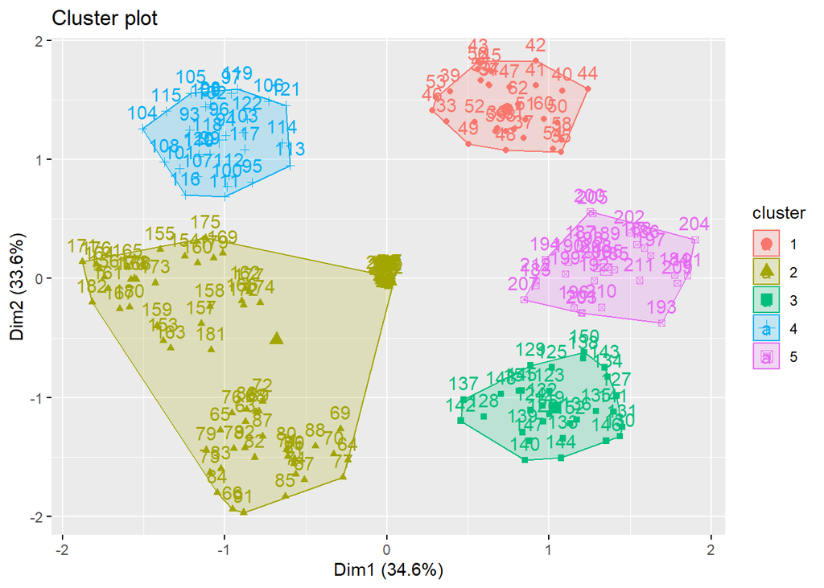

```r
fviz_cluster(clusters, data = copd.data.nomiss)
```

```r
#Show the mean value of features within each cluster
clusters$centers
```

```
##   pb_FEV1_pctpred  pct_br_resp        awt
## 1      2.99953830 -0.001130867 -0.1400596
## 2     -0.98022513  0.027156902  0.9679342
## 3      0.02271230 -2.968135967 -0.1117746
## 4      0.13998693  3.081746967  0.0745050
## 5     -0.04726217  0.045800633 -3.0427619
```

Remember, we set the # of clusters to be 5, so the algorithm forced all data into 5 clusters. From the plot, we can see that the yellow cluster is somewhat big and seems like it is made up of 3 different clusters. So, we should conduct a *gap_statistic analysis* to determine optimal number of clusters.

```r
set.seed(100)
gap_stat<-clusGap(copd.data.nomiss, FUN = kmeans, nstart = 25, K.max = 9, B = 50) # FUN = function; B = # of bootstraps
print(gap_stat, method = "firstmax")
```

```
## Clustering Gap statistic ["clusGap"] from call:
## clusGap(x = copd.data.nomiss, FUNcluster = kmeans, K.max = 9, B = 50, nstart = 25)
## B=50 simulated reference sets, k = 1..9; spaceH0="scaledPCA"
##  --> Number of clusters (method 'firstmax'): 7
##           logW   E.logW       gap     SE.sim
##  [1,] 5.282842 5.476391 0.1935487 0.01971434
##  [2,] 5.082621 5.292323 0.2097018 0.01967541
##  [3,] 4.914357 5.155441 0.2410837 0.02216689
##  [4,] 4.717145 5.037086 0.3199415 0.02172368
##  [5,] 4.462394 4.940356 0.4779614 0.02013570
##  [6,] 4.162681 4.854163 0.6914819 0.01925715
##  [7,] 3.825676 4.784056 0.9583801 0.01849430
##  [8,] 3.783336 4.724362 0.9410261 0.01803174
##  [9,] 3.748213 4.674145 0.9259322 0.01755657
```

```r
# The result provides us the optimal number of clusters, which is 7 in this demonstration.
# We can look at the result table. At 7 clusters, the value of gap is the highest (0.9583801)
```

Now we can go back to use our `kmeans` function and set seven clusters:

```r
clusters.7<-kmeans(copd.data.nomiss, 7, nstart = 25)

str(clusters.7)
```

```
## List of 9
##  $ cluster     : Named int [1:212] 7 7 7 7 7 7 7 7 7 7 ...
##   ..- attr(*, "names")= chr [1:212] "1" "2" "3" "4" ...
##  $ centers     : num [1:7, 1:3] 0.13999 -0.00631 0.02271 -0.04726 2.99954 ...
##   ..- attr(*, "dimnames")=List of 2
##   .. ..$ : chr [1:7] "1" "2" "3" "4" ...
##   .. ..$ : chr [1:3] "pb_FEV1_pctpred" "pct_br_resp" "awt"
##  $ totss       : num 1721
##  $ withinss    : num [1:7] 15.9 19.1 19 16.4 16.8 ...
##  $ tot.withinss: num 106
##  $ betweenss   : num 1615
##  $ size        : int [1:7] 30 30 30 30 30 30 32
##  $ iter        : int 2
##  $ ifault      : int 0
##  - attr(*, "class")= chr "kmeans"
```

```r
clusters.7
```

```
## K-means clustering with 7 clusters of sizes 30, 30, 30, 30, 30, 30, 32
##
## Cluster means:
##   pb_FEV1_pctpred  pct_br_resp          awt
## 1     0.139986933  3.081746967  0.074505000
## 2    -0.006311900  0.091942133  2.872362000
## 3     0.022712300 -2.968135967 -0.111774567
## 4    -0.047262167  0.045800633 -3.042761900
## 5     2.999538300 -0.001130867 -0.140059600
## 6    -2.995188400 -0.013736333  0.088239600
## 7    -0.004240719  0.004758156  0.007246719
##
## Clustering vector:
##   1   2   3   4   5   6   7   8   9  10  11  12  13  14  15  16  17  18  19  20
##   7   7   7   7   7   7   7   7   7   7   7   7   7   7   7   7   7   7   7   7
```

[output cut: 29 more lines]

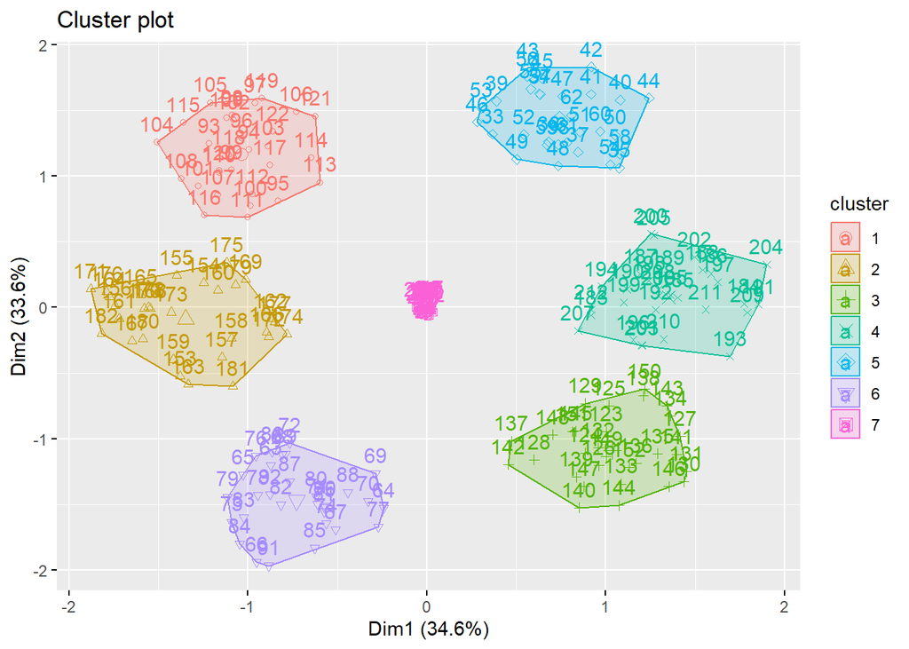

```r
fviz_cluster(clusters.7, data = copd.data.nomiss)
```

```r
# Now the clusters look more reasonable.
```

### Step 3: Conduct a hierarchical clustering analysis

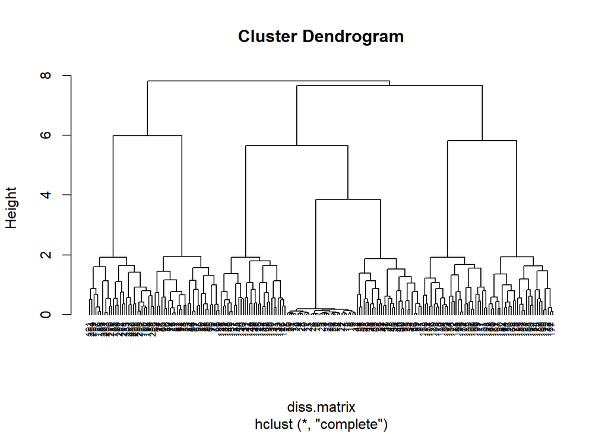

```r
# Create Dissimilarity matrix
diss.matrix <- dist(copd.data.nomiss, method = "euclidean")

# Hierarchical clustering using Complete Linkage
clusters.h<- hclust(diss.matrix, method = "complete" )

# Plot the obtained dendrogram
plot(clusters.h, cex = 0.6, hang = -1)
```

Now that we have the dendrogram, but how do we determine where in the height do we draw to obtain the optimal number of clusters? Use the *gap_statistic analysis* to find out!

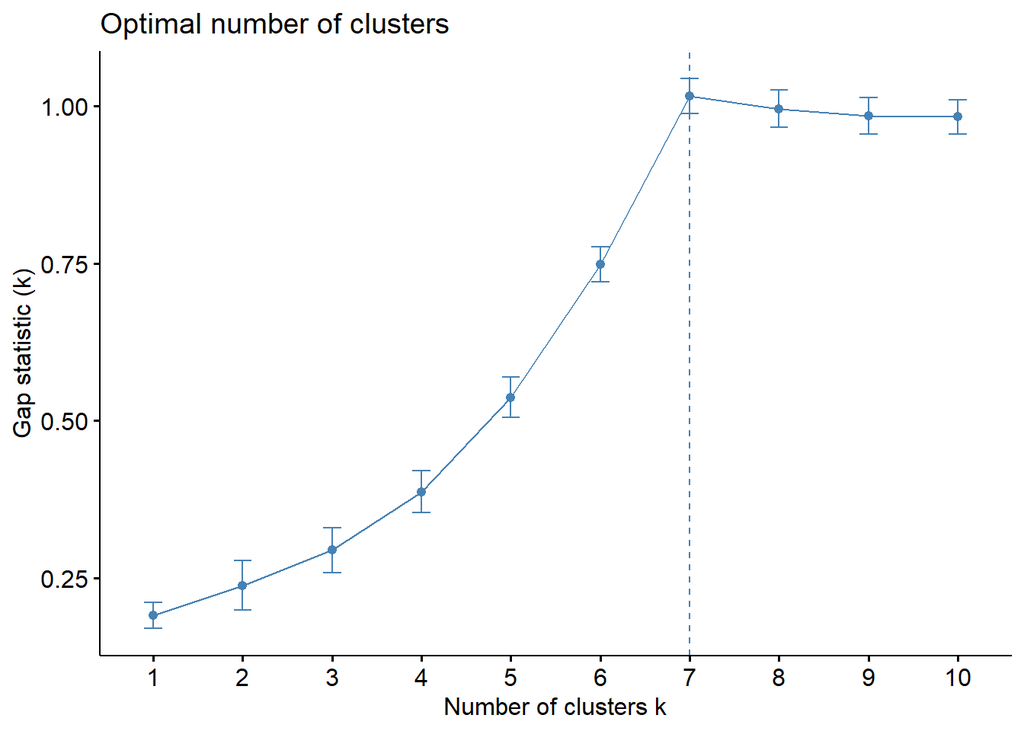

```r
#create function to use within clusGap
hclusCut <- function(x, k) list(cluster = cutree(hclust(dist(x, method="euclidian"), method="average"), k=k))

gap_stat <- clusGap(copd.data.nomiss, FUN = hclusCut, K.max = 10, B = 50)
fviz_gap_stat(gap_stat)
```

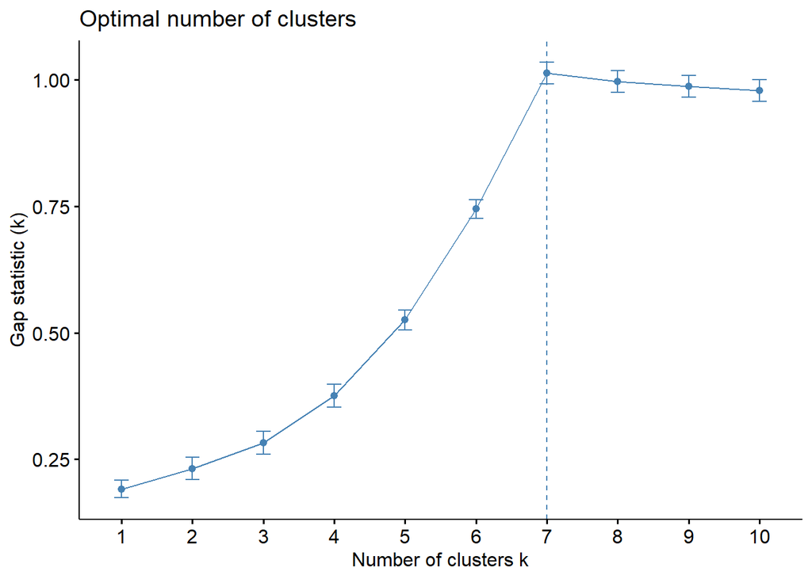

```r
# If I don't want to create a function, I can just state FUN = hcut.
gap_stat <- clusGap(copd.data.nomiss, FUN = hcut, K.max = 10, B = 50)
fviz_gap_stat(gap_stat)
```

After we obtain the optimal number of clusters, we can use number of clusters from gap statistic to obtain cluster assignment for each observation.

```r
clusters.h.7<-cutree(clusters.h, k=7)
table(clusters.h.7)
```

```
## clusters.h.7
##  1  2  3  4  5  6  7
## 32 30 30 30 30 30 30
```

Alternatives for hierarchical clustering:

```r
clusters.hcut<-hcut(copd.data.nomiss, k = 5, hc_func = "hclust", hc_method = "single", hc_metric = "euclidian")

clusters.hcut$size
```

```
## [1] 92 30 30 30 30
```

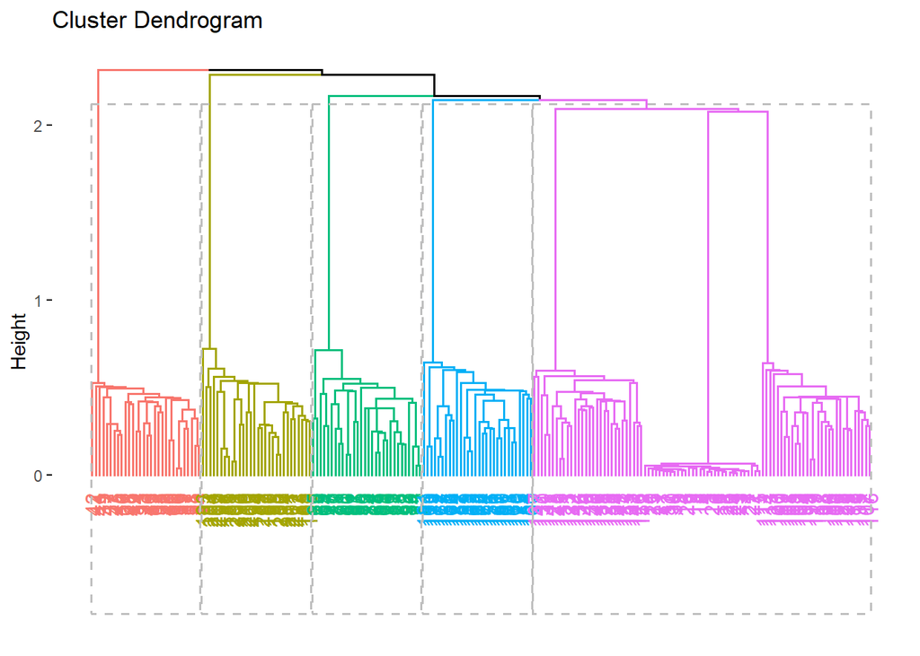

```r
fviz_dend(clusters.hcut, rect=TRUE)
```

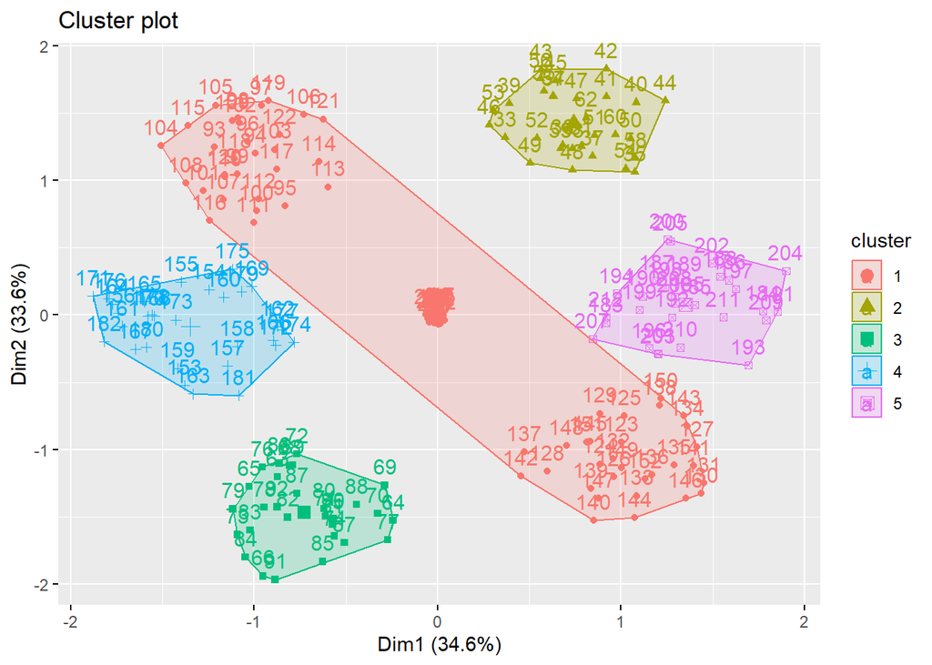

```r
fviz_cluster(clusters.hcut)
```

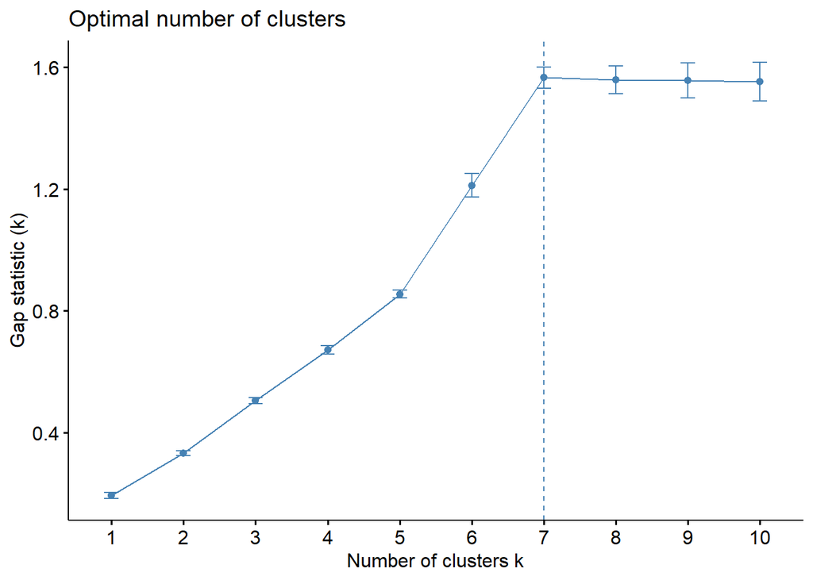

```r
gap_stat <- clusGap(copd.data.nomiss, FUN = hcut, hc_method="single", K.max = 10, B = 5)
fviz_gap_stat(gap_stat)
```

```r
input.feature.vals<-cbind(copd.data.nomiss,cluster=clusters.hcut$cluster)

input.feature.vals %>%
  group_by(cluster) %>%
  summarise_all(mean)
```

```
## # A tibble: 5 × 4
##   cluster pb_FEV1_pctpred pct_br_resp      awt
##     <int>           <dbl>       <dbl>    <dbl>
## 1       1         0.0516      0.0387  -0.00963
## 2       2         3.00       -0.00113 -0.140
## 3       3        -3.00       -0.0137   0.0882
## 4       4        -0.00631     0.0919   2.87
## 5       5        -0.0473      0.0458  -3.04
```

```r
#GENERAL SYNTAX
#input.feature.vals<-cbind(orig.data,cluster=cluster.object$cluster)

#input.feature.vals %>%
 # group_by(`cluster.object$cluster`) %>%
  #summarise_all(mean)
```